Skip to main content

# Data summary of my five flux towers

Author

Anastasia Kerber

Published

November 18, 2026

#| label: setup

```r
library(dplyr)
library(readr)
library(ggplot2)
library(tidyr)
library(maps)

# Funktion definieren
read_hh <- function(zip_file) {

  keep <- c(
    "TIMESTAMP_START", "TIMESTAMP_END", "TA_F", "SW_IN_F", "VPD_F", "P_F", "USTAR",
    "NETRAD", "G_F_MDS", "H_F_MDS", "H_F_MDS_QC", "LE_F_MDS", "LE_F_MDS_QC",
    "NEE_VUT_REF", "NEE_VUT_REF_QC", "GPP_NT_VUT_REF", "RECO_NT_VUT_REF"
  )

  site <- strsplit(basename(zip_file), "_")[[1]][2]

  hh_name <- grep(
    "FLUXMET_HH",
    unzip(zip_file, list = TRUE)$Name,
    value = TRUE)

  unzip(
    zip_file,
    files = hh_name,
    exdir = "data/raw/unzipped",
    overwrite = TRUE)

  hh <- read_csv(
    file.path("data/raw/unzipped", hh_name),
    na = "-9999",
    col_select = any_of(keep),
    col_types = cols(
      TIMESTAMP_START = "c",
      TIMESTAMP_END = "c",
      .default = "d"))

  # Add missing columns
  missing_cols <- setdiff(keep, names(hh))

  for (col in missing_cols) {
    hh[[col]] <- NA}

  # Put columns back in the desired order
  hh <- hh[, keep]

  hh <- hh |>
  rename(
    NEE  = NEE_VUT_REF,
    GPP  = GPP_NT_VUT_REF,
    RECO = RECO_NT_VUT_REF)

  hh <- hh |>
  mutate(
    site = site,
    time = as.POSIXct(
      TIMESTAMP_START,
      format = "%Y%m%d%H%M",
      tz = "UTC"
    )
  )
  return(hh)}

# alle Tower-Dateien finden
zip_files <- list.files("data/raw", pattern = "\\.zip$", full.names = TRUE)

countries <- c(US = "USA", CN = "China", FI = "Finnland", CD = "Kongo", AU = "Australien")

# alle Tower einlesen
all_hh <- do.call(rbind,lapply(zip_files, read_hh))

# Snapshot mit den Metadaten laden
snapshot <- read_csv("data/fluxnet_shuttle_snapshot_20261117T172817.csv",show_col_types = FALSE)

my_sites <- sort(unique(all_hh$site))

sites <- snapshot |>
  filter(site_id %in% my_sites) |>
  distinct(site_id, .keep_all = TRUE) |>
  mutate(country = countries[substr(site_id, 1, 2)])

sites |>
  select(`Site ID` = site_id, Name = site_name, Country = country, IGBP = igbp,
         `Lat (°)` = location_lat, `Lon (°)` = location_long,
         `First year` = first_year, `Last year` = last_year,
         Hub = data_hub, Citation = product_citation) |>
  knitr::kable(digits = 2)
```

| Site ID | Name | Country | IGBP | Lat (°) | Lon (°) | First year | Last year | Hub | Citation |
| --- | --- | --- | --- | --- | --- | --- | --- | --- | --- |
| US-SP1 | Slashpine-Austin Cary- 65yrs nat regen | USA | ENF | 29.74 | -82.22 | 2000 | 2020 | AmeriFlux | Rosvel Bracho, Timothy A. Martin (2026), AmeriFlux FLUXNET-1F US-SP1 Slashpine-Austin Cary- 65yrs nat regen, Ver. v1.3_r1 (2000-2020), AmeriFlux AMP, (Dataset). https://doi.org/10.17190/AMF/2469470 |
| CD-Ygb | Yangambi | Kongo | MF | 0.81 | 24.50 | 2020 | 2025 | ICOS | Boeckx, P., Bauters, M., Verbeeck, H., Boon, G., Bulonza, E., Daelman, R., Ekili, D., Kimbesa, F., Lefevre, L., Mbifo, J., Sibret, T., Van Damme, F. (2026). Fluxnet Archive Product from Yangambi, 2020… |
| FI-Qvd | Qvidja | Finnland | CRO | 60.30 | 22.39 | 2018 | 2023 | ICOS | Heimsch, L., Kulmala, L., Lohila, A. (2026). Fluxnet Archive Product from Qvidja, 2018–2023, FLUXNET, https://hdl.handle.net/11676/UuvYrldK3v4VzDgfH6nC0ed7 |
| CN-Du2 | Duolun_grassland (D01) | China | GRA | 42.05 | 116.28 | 2011 | 2019 | ICOS | Chen, S. (2026). Fluxnet Archive Product from Duolun_grassland (D01), 2011–2019, FLUXNET, https://hdl.handle.net/11676/4iVSvtAHibzF9fw90Vijm_Bi |
| AU-Wrr | Warra | Australien | EBF | -43.10 | 146.65 | 2013 | 2021 | TERN | Wardlaw, T., Phillips, A. (2026): Warra FLUXNET Release 2026_r1. Version 2026_r1. Terrestrial Ecosystem Research Network (TERN). (Dataset). |

# Data Summary Report

## Site Overview

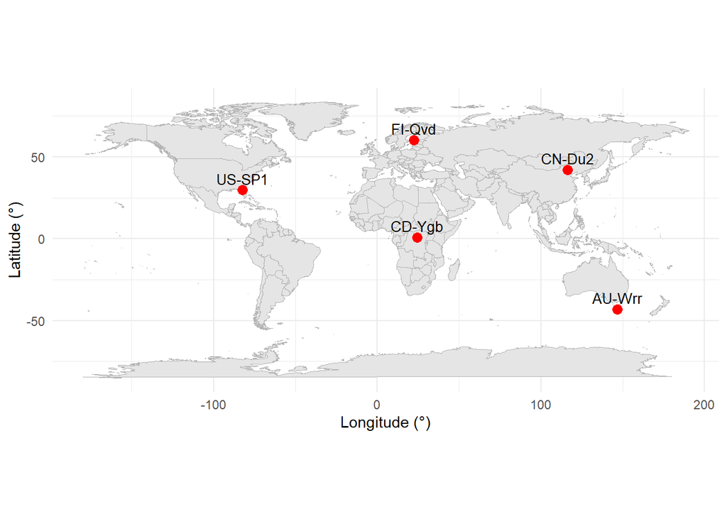

```r
#libraries
library (ggplot2)
library(tidyverse)
library(knitr)
library(here)

# map
world <- map_data("world")

ggplot() +
  geom_polygon(data = world, aes(long, lat, group = group),
               fill = "grey90", colour = "grey70", linewidth = 0.1) +
  geom_point(data = sites, aes(location_long, location_lat),
             colour = "red", size = 3) +
  geom_text(data = sites, aes(location_long, location_lat, label = site_id),
            nudge_y = 7, size = 3.5) +
  coord_quickmap() +
  labs(x = "Longitude (°)", y = "Latitude (°)") +
  theme_minimal()
```

```r
all_hh |>
  distinct(Site = site, `u* threshold` = "USTAR") |>
  knitr::kable()
```

| Site | u* threshold |
| --- | --- |
| US-SP1 | USTAR |
| CN-Du2 | USTAR |
| FI-Qvd | USTAR |
| CD-Ygb | USTAR |
| AU-Wrr | USTAR |

## Data Coverage

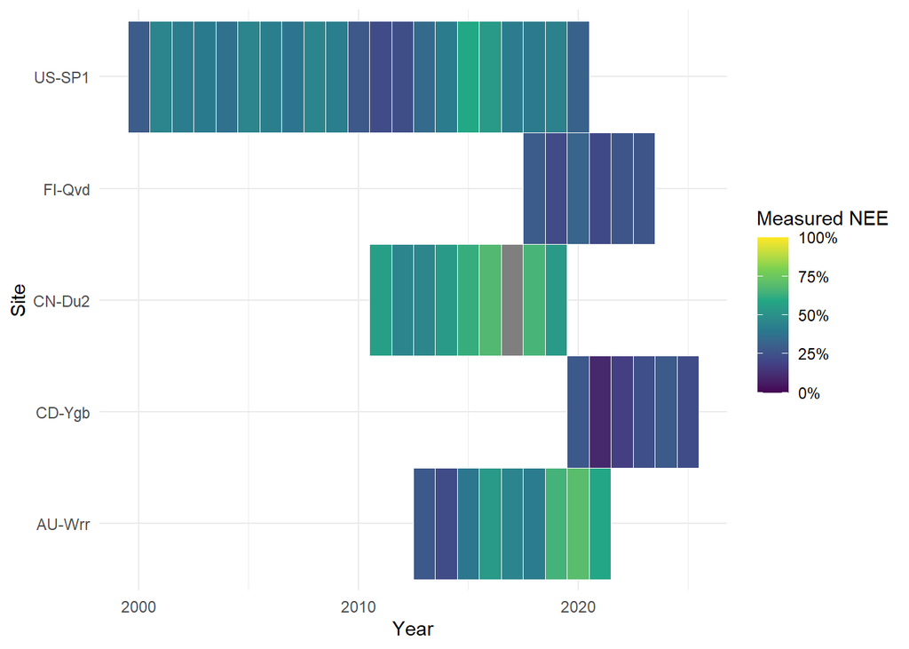

```r
coverage <- all_hh |>
  mutate(year = as.integer(format(time, "%Y"))) |>
  summarise(
    measured = mean(NEE_VUT_REF_QC == 0, na.rm = TRUE),
    .by = c(site, year))

ggplot(coverage, aes(year, site, fill = measured)) +
  geom_tile(colour = "white") +
  scale_fill_viridis_c(name = "Measured NEE", labels = scales::percent,
                       limits = c(0, 1)) +
  labs(x = "Year", y = "Site") +
  theme_minimal()
```

## Summary Statistics

```r
library(dplyr)
library(tidyr)

vars <- c(TA_F     = "TA_F (°C)",
          SW_IN_F  = "SW_IN_F (W m⁻²)",
          VPD_F    = "VPD_F (hPa)",
          P_F      = "P_F (mm)",
          NEE      = "NEE (µmol CO₂ m⁻² s⁻¹)",
          GPP      = "GPP (µmol CO₂ m⁻² s⁻¹)",
          RECO     = "RECO (µmol CO₂ m⁻² s⁻¹)",
          H_F_MDS  = "H (W m⁻²)",
          LE_F_MDS = "LE (W m⁻²)")

# Statistiken für alle Variablen und Türme
stats <- all_hh |>
  select(site, all_of(names(vars))) |>
  pivot_longer(-site, names_to = "var") |>
  summarise(Mean        = mean(value, na.rm = TRUE),
            Min         = min(value, na.rm = TRUE),
            Max         = max(value, na.rm = TRUE),
            `% missing` = 100 * mean(is.na(value)),
            .by = c(site, var))

# Niederschlag: mittlere Jahressumme statt Mittelwert
p_annual <- all_hh |>
  mutate(year = format(time, "%Y")) |>
  summarise(p_sum = sum(P_F, na.rm = TRUE), .by = c(site, year)) |>
  summarise(p_annual = mean(p_sum), .by = site)

stats <- stats |>
  left_join(p_annual, by = "site") |>
  mutate(Mean = if_else(var == "P_F", p_annual, Mean)) |>
  select(-p_annual)

# Eine Tabelle pro Turm
for (s in my_sites) {
  cat("\n\n### ", s, "\n\n", sep = "")
  tab <- stats |>
    filter(site == s) |>
    select(-site) |>
    mutate(var = vars[var]) |>
    pivot_longer(c(Mean, Min, Max, `% missing`), names_to = "Statistic") |>
    pivot_wider(names_from = var, values_from = value)
  cat(knitr::kable(tab, digits = 1), sep = "\n")
}
```

```
### AU-Wrr

|Statistic | TA_F (°C)| SW_IN_F (W m⁻²)| VPD_F (hPa)| P_F (mm)| NEE (µmol CO₂ m⁻² s⁻¹)| GPP (µmol CO₂ m⁻² s⁻¹)| RECO (µmol CO₂ m⁻² s⁻¹)| H (W m⁻²)| LE (W m⁻²)|
|:---------|---------:|---------------:|-----------:|--------:|----------------------:|----------------------:|-----------------------:|---------:|----------:|
|Mean      |      10.5|           131.1|         3.6|   1217.7|                   -0.1|                    6.9|                     6.7|       8.9|       48.5|
|Min       |      -1.1|             0.0|         0.0|      0.0|                  -74.8|                  -40.6|                     0.0|    -128.0|      -99.0|
|Max       |      38.2|          1224.0|        59.7|     19.6|                   49.9|                   84.7|                    43.8|     595.0|      595.0|
|% missing |       0.0|             0.0|         0.0|      0.0|                   18.9|                   18.9|                    18.9|      18.9|       18.5|


### CD-Ygb

|Statistic | TA_F (°C)| SW_IN_F (W m⁻²)| VPD_F (hPa)| P_F (mm)| NEE (µmol CO₂ m⁻² s⁻¹)| GPP (µmol CO₂ m⁻² s⁻¹)| RECO (µmol CO₂ m⁻² s⁻¹)| H (W m⁻²)| LE (W m⁻²)|
|:---------|---------:|---------------:|-----------:|--------:|----------------------:|----------------------:|-----------------------:|---------:|----------:|
|Mean      |      24.8|           181.7|       973.9|   1965.2|                    0.6|                    NaN|                     NaN|      23.2|       84.1|
|Min       |      18.6|             0.0|         0.0|      0.0|                  -71.9|                    Inf|                     Inf|    -294.3|     -221.0|
|Max       |      35.0|          1159.7|      3001.0|    107.7|                   49.8|                   -Inf|                    -Inf|     648.9|      920.9|
|% missing |       0.0|             0.0|         0.0|      0.0|                   18.2|                    100|                     100|      18.1|       18.2|


### CN-Du2

|Statistic | TA_F (°C)| SW_IN_F (W m⁻²)| VPD_F (hPa)| P_F (mm)| NEE (µmol CO₂ m⁻² s⁻¹)| GPP (µmol CO₂ m⁻² s⁻¹)| RECO (µmol CO₂ m⁻² s⁻¹)| H (W m⁻²)| LE (W m⁻²)|
|:---------|---------:|---------------:|-----------:|--------:|----------------------:|----------------------:|-----------------------:|---------:|----------:|
|Mean      |       3.0|           192.9|         5.5|    474.7|                   -0.2|                    1.2|                     1.0|      36.3|       30.8|
|Min       |     -36.3|             0.0|         0.0|      0.0|                  -68.0|                  -48.3|                     0.0|    -132.2|     -286.7|
|Max       |      34.5|          1179.6|        47.3|     35.7|                   49.4|                   68.6|                    12.1|     463.7|      597.9|
|% missing |       0.0|             0.0|         0.0|      0.0|                   13.9|                   13.9|                    13.9|      13.8|       13.8|


### FI-Qvd

|Statistic | TA_F (°C)| SW_IN_F (W m⁻²)| VPD_F (hPa)| P_F (mm)| NEE (µmol CO₂ m⁻² s⁻¹)| GPP (µmol CO₂ m⁻² s⁻¹)| RECO (µmol CO₂ m⁻² s⁻¹)| H (W m⁻²)| LE (W m⁻²)|
|:---------|---------:|---------------:|-----------:|--------:|----------------------:|----------------------:|-----------------------:|---------:|----------:|
|Mean      |       6.8|           116.9|         3.3|    697.3|                    0.4|                    3.8|                     4.1|       8.3|       27.5|
|Min       |     -25.6|             0.0|         0.0|      0.0|                  -54.0|                  -46.6|                     0.0|    -241.2|     -181.7|
|Max       |      32.5|           940.2|        36.1|     19.9|                   48.3|                   59.3|                    38.1|     547.0|      519.5|
|% missing |       0.0|             0.0|         0.0|      0.0|                    4.8|                    4.8|                     4.8|       4.8|        4.8|


### US-SP1

|Statistic | TA_F (°C)| SW_IN_F (W m⁻²)| VPD_F (hPa)| P_F (mm)| NEE (µmol CO₂ m⁻² s⁻¹)| GPP (µmol CO₂ m⁻² s⁻¹)| RECO (µmol CO₂ m⁻² s⁻¹)| H (W m⁻²)| LE (W m⁻²)|
|:---------|---------:|---------------:|-----------:|--------:|----------------------:|----------------------:|-----------------------:|---------:|----------:|
|Mean      |      20.4|           189.9|         7.1|   1654.7|                   -0.9|                    4.3|                     3.5|      37.1|       59.1|
|Min       |    -243.7|             0.0|         0.0|      0.0|                  -79.5|                  -47.1|                     0.0|    -199.9|     -209.5|
|Max       |      37.5|          1223.0|        49.3|     97.8|                   50.0|                   81.7|                    62.8|     992.4|      991.5|
|% missing |       0.0|             0.0|         0.0|      0.0|                    7.1|                    7.1|                     7.1|       6.6|        6.6|
```

```r
# Mean annual precipitation sum

precip_summary <- all_hh |>
  mutate(
    year = as.integer(format(time, "%Y"))
  ) |>
  group_by(site, year) |>
  summarise(
    annual_precip_mm = sum(P_F, na.rm = TRUE),
    .groups = "drop"
  ) |>
  group_by(site) |>
  summarise(
    `P_F Mean annual sum (mm)` = mean(annual_precip_mm, na.rm = TRUE),
    `P_F Min annual sum (mm)`  = min(annual_precip_mm, na.rm = TRUE),
    `P_F Max annual sum (mm)`  = max(annual_precip_mm, na.rm = TRUE),
    `P_F Missing (%)` = 100 * mean(is.na(all_hh$P_F[all_hh$site == first(site)]))
  )

precip_summary
```

```
# A tibble: 5 × 5
  site   P_F Mean annual sum (mm…¹ P_F Min annual sum (…² P_F Max annual sum (…³
  <chr>                      <dbl>                  <dbl>                  <dbl>
1 AU-Wrr                     1218.                  1053.                  1516.
2 CD-Ygb                     1965.                  1604.                  2527.
3 CN-Du2                      475.                   297.                   703.
4 FI-Qvd                      697.                   545.                   817.
5 US-SP1                     1655.                   335.                  4731.
# ℹ abbreviated names: ¹`P_F Mean annual sum (mm)`, ²`P_F Min annual sum (mm)`,
#   ³`P_F Max annual sum (mm)`
# ℹ 1 more variable: `P_F Missing (%)` <dbl>
```

## Time Series

Half-hourly carbon fluxes were aggregated to daily means for each site and converted from µmol CO₂ m⁻² s⁻¹ to g C m⁻² d⁻¹ using a conversion factor of 1.0378.

### Daily aggregation

```r
daily <- all_hh |>
  mutate(date = as.Date(time)) |>
  summarise(across(c(NEE, GPP, RECO), ~ mean(.x) * 1.0378),
            .by = c(site, date))
```

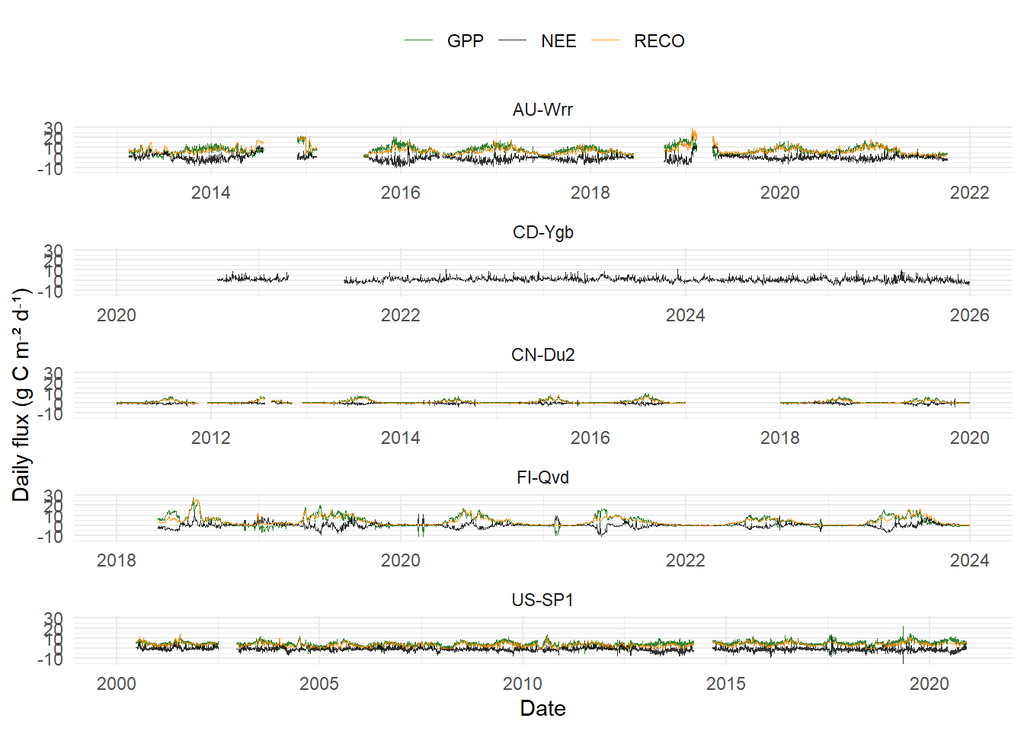

```r
daily |>
  pivot_longer(c(NEE, GPP, RECO), names_to = "flux") |>
  ggplot(aes(date, value, colour = flux)) +
  geom_line(linewidth = 0.2, alpha = 0.8) +
  facet_wrap(~ site, ncol = 1, scales = "free_x") +
  scale_colour_manual(values = c(GPP = "darkgreen", RECO = "darkorange", NEE = "black")) +
  labs(x = "Date", y = "Daily flux (g C m⁻² d⁻¹)", colour = NULL) +
  theme_minimal() +
  theme(legend.position = "top")
```

### Validation against FLUXMET_DD

To verify the aggregation procedure, daily values derived from the half-hourly records were compared with the corresponding daily product for one site (CN-Du2).

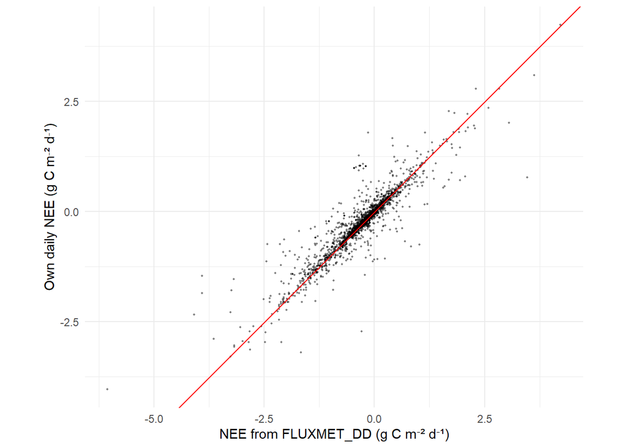

```r
z       <- list.files("data/raw", pattern = "CN-Du2.*\\.zip$", full.names = TRUE)
dd_name <- grep("FLUXMET_DD", unzip(z, list = TRUE)$Name, value = TRUE)

dd <- read_csv(unz(z, dd_name), na = "-9999",
               col_select = c(TIMESTAMP, NEE_VUT_REF),
               col_types = cols(TIMESTAMP = "c", .default = "d")) |>
  mutate(date = as.Date(TIMESTAMP, format = "%Y%m%d"))

cmp <- daily |>
  filter(site == "CN-Du2") |>
  inner_join(dd, by = "date")

ggplot(cmp, aes(NEE_VUT_REF, NEE)) +
  geom_point(size = 0.4, alpha = 0.4) +
  geom_abline(slope = 1, intercept = 0, colour = "red") +
  labs(x = "NEE from FLUXMET_DD (g C m⁻² d⁻¹)",
       y = "Own daily NEE (g C m⁻² d⁻¹)") +
  coord_equal() +
  theme_minimal()
```

## Diurnal cycles

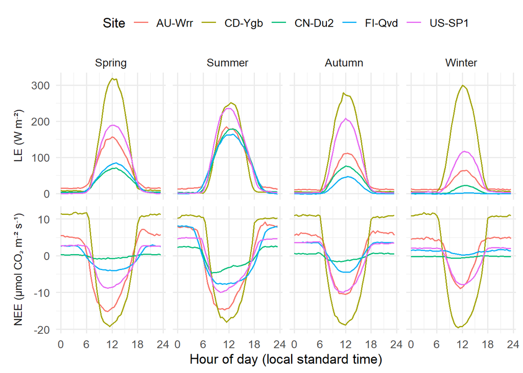

```r
season_nh <- c("Winter", "Winter", "Spring", "Spring", "Spring", "Summer",
               "Summer", "Summer", "Autumn", "Autumn", "Autumn", "Winter")

diurnal <- all_hh |>
  left_join(sites |> select(site = site_id, lat = location_lat), by = "site") |>
  mutate(month  = as.integer(format(time, "%m")),
         # Südhalbkugel: Monate um 6 verschieben (Januar -> Juli usw.)
         month_adj = if_else(lat < 0, (month + 5) %% 12 + 1, month),
         season = factor(season_nh[month_adj],
                         levels = c("Spring", "Summer", "Autumn", "Winter")),
         hour   = as.numeric(format(time, "%H")) + as.numeric(format(time, "%M")) / 60) |>
  summarise(`NEE (µmol CO₂ m⁻² s⁻¹)` = mean(NEE, na.rm = TRUE),
            `LE (W m⁻²)`             = mean(LE_F_MDS, na.rm = TRUE),
            .by = c(site, season, hour))

diurnal |>
  pivot_longer(-c(site, season, hour), names_to = "variable") |>
  ggplot(aes(hour, value, colour = site)) +
  geom_line(linewidth = 0.7) +
  facet_grid(variable ~ season, scales = "free_y", switch = "y") +
  scale_x_continuous(breaks = seq(0, 24, 6)) +
  labs(x = "Hour of day (local standard time)", y = NULL, colour = "Site") +
  theme_minimal(base_size=13) +
  theme(strip.placement = "outside", legend.position = "top")
```

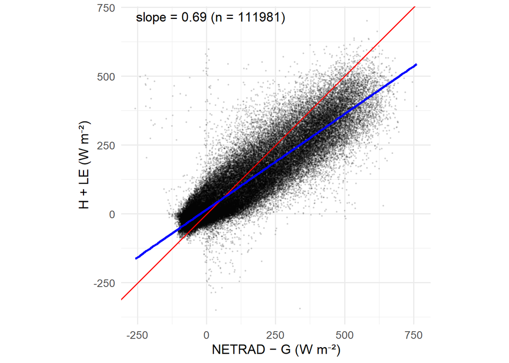

```r
eb <- all_hh |>
  filter(site == "CN-Du2", H_F_MDS_QC == 0, LE_F_MDS_QC == 0) |>
  mutate(available = NETRAD - G_F_MDS,
         turbulent = H_F_MDS + LE_F_MDS) |>
  filter(!is.na(available), !is.na(turbulent))

fit   <- lm(turbulent ~ available, data = eb)
slope <- coef(fit)[["available"]]

ggplot(eb, aes(available, turbulent)) +
  geom_point(size = 0.3, alpha = 0.1) +
  geom_abline(slope = 1, intercept = 0, colour = "red") +
  geom_smooth(method = "lm", colour = "blue", se = FALSE) +
  annotate("text", x = -Inf, y = Inf, hjust = -0.1, vjust = 1.5,
           label = paste0("slope = ", round(slope, 2), " (n = ", nrow(eb), ")")) +
  labs(x = "NETRAD − G (W m⁻²)", y = "H + LE (W m⁻²)") +
  coord_equal() +
  theme_minimal(base_size = 13)
```

## Data and Citation

Data citations for my towers (from the FLUXNET Shuttle snapshot):

AU-Wrr: Wardlaw, T., Phillips, A. (2026): Warra FLUXNET Release 2026_r1. Version 2026_r1. Terrestrial Ecosystem Research Network (TERN). (Dataset).

US-SP1: Rosvel Bracho, Timothy A. Martin (2026), AmeriFlux FLUXNET-1F US-SP1 Slashpine-Austin Cary- 65yrs nat regen, Ver. v1.3_r1 (2000-2020), AmeriFlux AMP, (Dataset). https://doi.org/10.17190/AMF/2469470

CD-Ygb: Boeckx, P., Bauters, M., Verbeeck, H., Boon, G., Bulonza, E., Daelman, R., Ekili, D., Kimbesa, F., Lefevre, L., Mbifo, J., Sibret, T., Van Damme, F. (2026). Fluxnet Archive Product from Yangambi, 2020–2025, FLUXNET, https://hdl.handle.net/11676/4yxFg7HiX3wwcXY7t16U5Jec

CN-Du2: Chen, S. (2026). Fluxnet Archive Product from Duolun_grassland (D01), 2011–2019, FLUXNET, https://hdl.handle.net/11676/4iVSvtAHibzF9fw90Vijm_Bi

FI-Qvd: Heimsch, L., Kulmala, L., Lohila, A. (2026). Fluxnet Archive Product from Qvidja, 2018–2023, FLUXNET, https://hdl.handle.net/11676/UuvYrldK3v4VzDgfH6nC0ed7

Also cite: Pastorello et al. (2020), Scientific Data 7, 225, https://doi.org/10.1038/s41597-020-0534-3

FLUXNET data products were produced and harmonized by eddy covariance regional networks and data processing centers, including AmeriFlux, ChinaFlux, European Fluxes Database, ICOS, JapanFlux, KoFlux, OzFlux, SAEON, and TERN. These products also include a modified version of ERA5 hourly data provided by the Copernicus Climate Change Service.